# 2015 Biotropica Awards for Excellence in Tropical Biology and Conservation - 2015 - Biotropica - Wiley Online Library

[Biotropica](https://onlinelibrary.wiley.com/journal/17447429)

[Volume 47, Issue 6](https://onlinelibrary.wiley.com/toc/17447429/2015/47/6) p. 779-782

[figure not shown]

Announcement

Full Access

# 2015 *Biotropica* Awards for Excellence in Tropical Biology and Conservation

First published: 28 October 2015

https://doi.org/10.1111/btp.12291

Every year *Biotropica*’s Editorial Board selects the recipient of the Award for Excellence in Tropical Biology and Conservation, which recognizes the outstanding paper published in our journal in the previous calendar year. In addition, this year the Editorial Board voted to create a new award for the outstanding article by a student in recognition of the passion and creativity of these early career scholars. Criteria for selecting the papers to receive these awards include clarity of presentation, a strong basis in natural history, well-planned experimental or sampling design, and the novel insights gained into critical processes that influence the structure, functioning, or conservation of tropical systems.

In the following essays, the authors of the award-winning articles and the Subject Editors that worked with them describe what captured their attention, what inspired the study, and how they hope the work will inspire other researchers. We hope you enjoy these insights into the process that resulted in such novel and interesting work, and congratulations to our 2015 award winners on behalf of the Editorial Board and the Association for Tropical Biology and Conservation.

**Emilio Bruna**, Editor-in-Chief

University of Florida,

Gainesville, USA

**Farwig, N., Lung, T., Schaab, G. and Böhning-Gaese, K. (2014),** *Linking Land-Use Scenarios, Remote Sensing and Monitoring to Project Impact of Management Decisions. Biotropica*, 46: 357–366.

Landscape conservation planning has a vital role to play in helping guide strategic decisions over the spatial distribution of conservation interventions, and the relative biodiversity implications of alternative options. However, research on conservation planning all too often remains a largely academic exercise of limited practical relevance. There are a multitude of reasons for this but high among them is that the set of management options analyzed is often a very poor reflection of the actual options that exist for change on the ground. Another common limitation is that many studies depend primarily on one type of observation or data from which to draw their conclusions.

Nina Farwig and colleagues sought to address both of these limitations in their insightful study of the biodiversity consequences of forest management options in Kakamega Forest, Kenya. The key innovation of their paper is combining remote sensing data on the spatial distribution of forest management types, avian field surveys, and stakeholder interviews to offer meaningful guidance on the conservation outcomes of alternative management options facing local stakeholders. This blending of methods seems an entirely logical way to support a conservation decision making process, yet it is sadly all too rare in the literature.

The authors used linear models to extrapolate spatial patterns of species richness and community composition to visualize biodiversity outcomes for five different forest management scenarios that encompassed the full range of possible outcomes, including the most extreme cases—complete production or complete protection. They found that a spatially explicit representation of projected bird diversity, in particular of community composition, offered the most visually meaningful expression of the potential biodiversity consequences of forest management decisions. I was impressed that Farwig and her colleagues are open about the limitations of their approach. Yet rather than assume that these limitations make it impossible to draw meaningful summaries of biodiversity information at scales that are relevant to management, they managed to construct a simplified yet highly accessible summary of likely changes in biodiversity in response to a wide range of plausible management outcomes. The outcome is a very readable paper, presenting both management relevant conclusions and serving as a constructive guide for other readers of *Biotropica* to be a bit more adventurous. I congratulate Farwig and all co-authors for their work and the prize, which they fully deserve.

**Toby Gardner**

*Stockholm Environment Institute,*

*Stockholm, Sweden*

My first contact with tropical ecology was during an internship in Madagascar where I was following mouse lemurs to study their feeding ecology. I was fascinated by the diversity and complexity of tropical ecosystems and started working with Prof. Katrin Böhning-Gaese, who supervised my graduation thesis on the pollination ecology of a dioecious Malagasy tree species. During this second stay in Madagascar I was delighted to climb up and down many *Commiphora* trees, this time to observe their tiny flowers for flower visitors. However, I also noticed that, just 2 years after my first stay, strong changes across the island had led to a dramatic loss of natural ecosystems, an experience that marked my future life as a conservation ecology researcher.

I was, thus, more than happy that during my Ph.D. I was able to continue working in a tropical forest ecosystem—this time in Kenya within the interdisciplinary research project BIOTA (BIOdiversity Transect Analysis in Africa – [www.biota-africa.org](http://www.biota-africa.org/)). Continuing to work with Katrin, I was now not only dealing with a basic ecology, but with an applied research question that considered changes in forest ecosystems: The impact of forest fragmentation and disturbance on the endangered tropical tree *Prunus africana*. During my work in Kenya I studied how different processes within the regeneration loop of this endangered tree species as well as the genetic diversity are affected by fragmentation and logging. These findings and further data that we collected within the subproject of BIOTA revealed that the surrounding landscape, for example, proportion of remaining forest, matrix heterogeneity, intensity of logging, is an important factor determining the persistence of biodiversity in modern landscapes.

As our interdisciplinary team within BIOTA comprised both experienced field ecologists as well as remote sensing and spatial data modeling experts we decided to use this landscape perspective for applied conservation planning within the framework of the Kakamega Forest Ecosystem Management Plan. The planning process provided the required background for compiling adequate scenarios considering different needs and interests as all important stakeholder groups such as the local community, the managing authorities as well as scientists participated. My postdoctoral work within Katrin's lab had shown considerable differences in both the proportion of forest birds and in community structure of the avifauna among differently modified forest types, that is, primary and secondary forests, native and invasive plantations. Thus, we aimed to link these sensitive bird diversity measures to a broader set of geo-spatial properties that describe the composition and configuration of forests in the landscape using geographical information systems (GIS). In other words, we used community-level modeling to spatially extrapolate and visualize bird diversity measures based on forest properties across the complete protected forest area of Kakamega Forest to develop spatially explicit projections of future biodiversity under different land-use scenarios.

**Nina Farwig**

*University of Marburg,*

*Marburg, Germany*

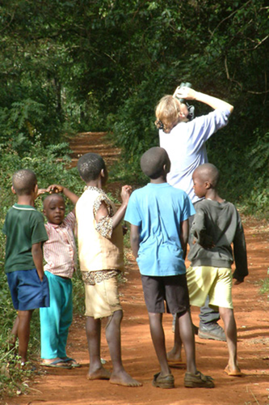

Nina Farwig and local children (Photo by Sascha Rösner)

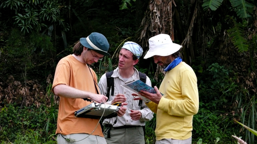

Tobias Lung (center) and colleagues (Photo by Gertrud Schaab)

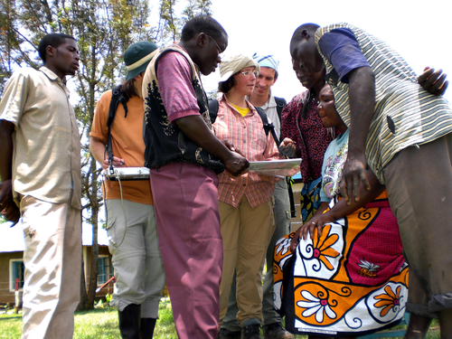

Gertrud Schaab, Tobias Lung, and community members (Photo by Nick Mitchell)

**Maruyama, P. K., Vizentin-Bugoni, J., Oliveira, G. M., Oliveira, P. E. and Dalsgaard, B. (2014),** *Morphological and Spatio-Temporal Mismatches Shape a Neotropical Savanna Plant-Hummingbird Network*. *Biotropica*, 46: 740–747.

Analyses of complex ecological interaction networks have become fashionable among ecologists. However, how such analyses—often burrowed from other disciplines and motivated by complex graphs—can really contribute to a realistic understanding of interactions in communities remains controversial. Although many studies of networks simply describe the networks (*e.g*., the degree of “nestedness”) and only speculate about mechanisms, I feel the greatest contribution comes from studies that relate the interaction pattern to possible underlying processes and mechanisms in an explicit, quantitative way. The paper by Pietro Maruyama and his co-authors on hummingbird–flower interactions in a Brazilian Cerrado landscape exemplifies this approach to understanding the biology behind a network. They first used up-to-date and quantitative metrics to describe the network, then used null models and a powerful statistical analysis of the contribution of different traits. The results show that spatio-temporal overlap is an important predictor of the interaction frequencies, as is the match between corolla length of flowers and bill lengths of the birds. Although this finding is not unexpected, their analysis allowed an explicit comparison of these traits with species’ abundances and nectar quantity and quality, both of which seem to play a minor role in predicting interaction frequencies.

Such a thorough analysis of interaction networks is not new, but it is very rare. As such, Maruyama et al.'s approach may serve as template for future studies trying to understand the drivers behind network patterns. Hummingbird-flower networks are a perfect model for analyzing such interactions, in part because one can get a very clear idea about the roles and impacts of bill length and other species traits. Of course, these are only some of many reasons to read Pietro Maruyama's paper, and I have yet to mention one more with which tropical biologists will surely agree. Hummingbirds and the flowers they interact with are undoubtedly one of the most charming and fascinating study systems in the tropics.

Congratulations to PhD student Pietro Maruyama from the University of Campinas and his collaborators for such a well-performed study and their important paper. It is a worthy recipient of the inaugural award for the Outstanding Student Article.

**Nico Blüthgen**

*Technical University Darmstadt,*

*Darmstadt, Germany*

I still remember the first time I noticed a hummingbird—I was in my late teens at my grandparents’ house in Brazil. As someone who spent most of his childhood in Japan, I recall how impressed I was when I saw this incredibly small bird drinking sugar water from an artificial feeder. Some years later, I began studying the pollination biology of Cerrado plants under the supervision of Paulo E. Oliveira during my undergraduate studies at the Universidade Federal de Uberlândia (UFU). I started to study plants pollinated by hummingbirds during my Master thesis, which eventually led me to join Marlies Sazima's Lab at University of Campinas (Unicamp) as a Ph.D. student. Here, I have continued my research on plant-hummingbird interactions with new collaborators, including Unicamp's Jeferson Vizentin-Bugoni and Bo Dalsgaard from the Natural History Museum of Denmark.

There are many textbook examples of tight co-adaptation between flowers and hummingbirds, such as the association between the Sword-billed hummingbird (*Ensifera ensifera*) and some extremely long-tubed Andean flowers, or the striking sexual dimorphism found in the Lesser Antillean Purple-throated Carib (*Eulampis jugularis*) associated with floral phenotype of two species of *Heliconia*. We concluded in a previous study that plant-hummingbird interactions in the Brazilian Atlantic Rainforest, although specialized, were better predicted by species traits than by the abundance of the species. This is counter to what is typically found in other types of ecological networks.

To test the importance of distinct processes on structuring interactions in a network is no trivial matter—besides data on the interactions themselves, one needs a distinct dataset on the species in the network, such as morphological traits, the spatio-temporal distribution of species, and their abundance. These data can be hard to collect or find in the literature. It was therefore a welcome surprise when we realized that Genilda Oliveira, a former student of Paulo's at Universidade de Brasília now at the Instituto Federal do Triângulo Mineiro in Uberlândia, had these data for a Cerrado plant–hummingbird community. In contrast to neighboring rainforest ecosystems, such as the Amazon and Atlantic Forests, hummingbirds from Cerrado seem to be generalists relying on plants with little phenotypical adaptation toward bird-pollination. Moreover, the Cerrado biome is characterized by the patchy distribution of different habitats, which makes it a good model system to test the relative importance of species habitat preferences, morphology, phenology, and abundance for structuring species interactions. By putting together our complementary expertise on natural history and network analyses, we were able to approach this interesting question with a comprehensive approach.

We found that species interactions are best predicted by morphological matches, phenology, and the habitat occupancy of species, whereas species abundances and nectar availability are poor predictors of interactions. Moreover, the Cerrado plant-hummingbird network is organized in sub-units that are associated with morphological specialization and habitat occupancy. Interactions between short-billed hummingbirds and short corolla plants predominate in the more typical open savanna habitats, whereas forest habitats are occupied by the long-billed and thus morphologically more specialized Planalto hermit (*Phaethornis pretrei*) and a subset of more specialized ‘ornithophilous’ plants.

That species traits are important in organizing plant-hummingbird interactions in ecosystems as different as the Cerrado and Atlantic Forest has led us to propose that traits matter more in tropical plant–hummingbird networks than in other, less specialized systems. We hope that this study will encourage other researchers to test the generality of this hypothesis by contrasting ecological networks with differences in the level of specialization or ‘intimacy’, for instance by conducting comparisons across geographic regions and interactions.

**Pietro K. Maruyama**

*University of Campinas,*

*Campinas, Brazil*

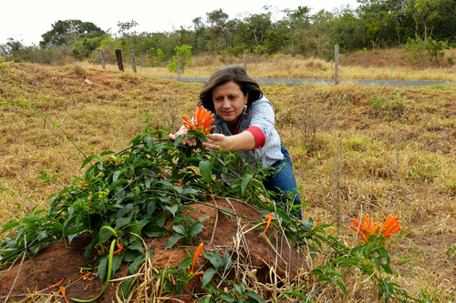

Genilda M. Oliveira (Photo by Welber Moitinho Dias)

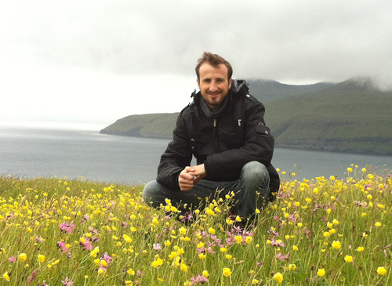

Jeferson Vizentin-Bugoni (photo by Juliana Cordeiro)

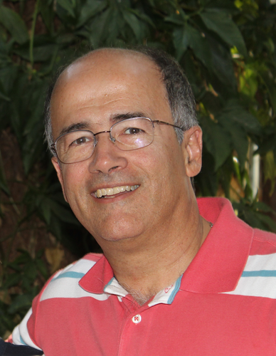

Paulo E. Oliveira (Photo by Paulo Oliveira)

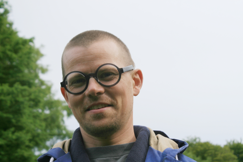

Bo Dalsgaard (Photo by Marie Sorivelle)

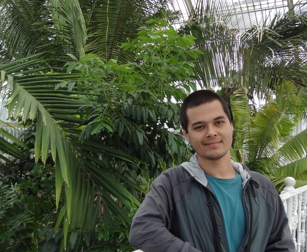

Pietro K. Maruyama (Photo by Amanda F. Cunha)

[figure not shown]

[Volume47, Issue6](https://onlinelibrary.wiley.com/toc/17447429/2015/47/6)

November 2015

Pages 779-782